# First data attempts for IUCN project

First, we grab the ISO country names from WB and regional codes (i.e. West and Central Africa) from UN and combine them, resulting in a vector of codes for the countries we are interested in.

Then we grab some data using the API for the world bank WDIs (World Development Indicators,also available at google public data).

Then we standardise them so that the mean is always zero and standard deviation 1, to make comparison between indicators easier.

The first chart shows time series for this first batch of indicators.

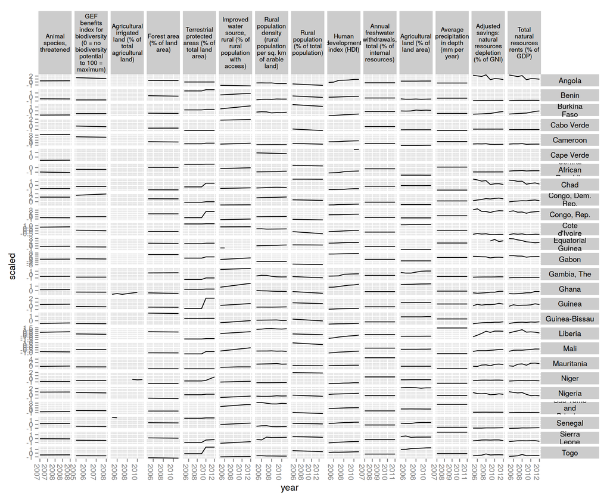

The second graph is the beginning of an attempt to group the countries and indicators into meaningful clusters. Obviously we will need more indicators to make this useful. We extract only the latest data for each country for each indicator.

TODO:

- Note countries with any missing data are excluded here - that needs fixing.
- Merge Cabo Verde and Cape Verde

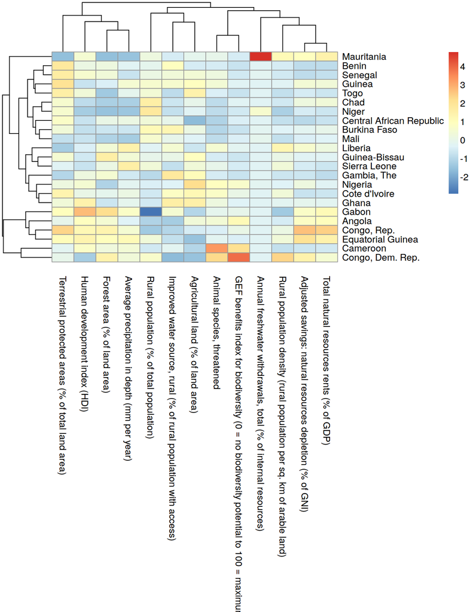

There isn’t much grouping of indicators - the joins are quite high up in the dendrogram on the x axis. But the countries do cluster.

```r
library(RColorBrewer)
data=(data.frame(xx=rownames(c),yy=c[,1]))
# worldmap(data)
# worldmap(data,mapTitle = "",breaks=-3:3,labels=xc("a b c d e f"))
```

## Species maps using gbif

```r
# key <- name_backbone(name='Puma concolor')$speciesKey
# dat <- occ_search(taxonKey=key, return='data', limit=300)
# gbifmap(input=dat)
#
# gbifmap(input=dat,region="Burkina Faso")
# (burk<- isocodes[grep("Burkina", isocodes$name), "code"])
# dat <- occ_search(country=burk, return='data', limit=300)
```